# pdpbox-0-数据探索性分析

原创教程，版权所有。

同济子豪兄B站视频专栏：https://space.bilibili.com/1900783

玩转UCI心脏病二分类数据集，课件、代码、答疑互动：https://t.zsxq.com/Z7yNZBu

子豪兄Python交流QQ群：1077638784

子豪兄Kaggle数据科学竞赛交流：481041896

微信公众号：人工智能小技巧

2020-05-15

# 本节概述

使用pdpbox工具包，对uci心脏病数据集进行探索性数据分析，分析不同特征与患心脏病之间的先验关系，并分析特征两两之间的影响关系。

我们还没有开始正式训练模型，本小节仅是对数据集进行初步先验分析。

# 导入工具包，导入数据集

```python
import numpy as np
import pandas as pd

import matplotlib.pyplot as plt
%matplotlib inline

# 忽略烦人的红色提示
import warnings
warnings.filterwarnings("ignore")

# 忽略烦人的红色提示
import warnings
warnings.filterwarnings("ignore")

df = pd.read_csv('process_heart.csv')
```

# 导入pdpbox工具包

```python
from pdpbox import pdp, get_dataset, info_plots
```

特征：性别

该特征统计分布，及患心脏病和不患心脏病类别分布图。

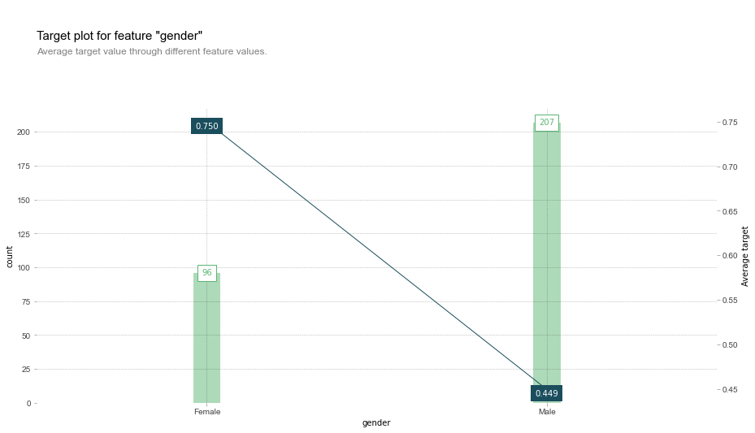

```python
fig, axes, summary_df = info_plots.target_plot(
    df=df, feature='sex_male', feature_name='gender', target=['target']
)
_ = axes['bar_ax'].set_xticklabels(['Female', 'Male'])
```

```python
summary_df
```

|  | x | display_column | count | target |
| --- | --- | --- | --- | --- |
| 0 | 0 | sex_male_0 | 96 | 0.750000 |
| 1 | 1 | sex_male_1 | 207 | 0.449275 |

特征：心脏周围大血管的个数

该特征统计分布，及患心脏病和不患心脏病类别分布图。

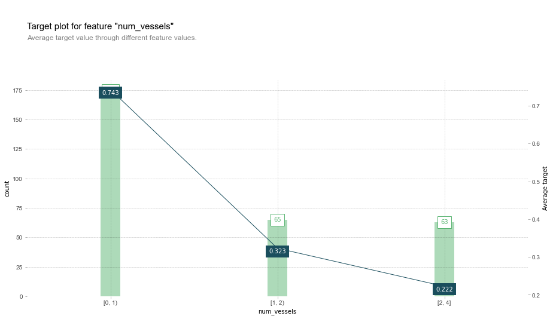

```python
fig, axes, summary_df = info_plots.target_plot(
    df=df, feature='num_major_vessels', feature_name='num_vessels', target=['target']
)
# _ = axes['bar_ax'].set_xticklabels(['Female', 'Male'])
```

特征：地中海贫血症-reversable defect

该特征统计分布，及患心脏病和不患心脏病类别分布图。

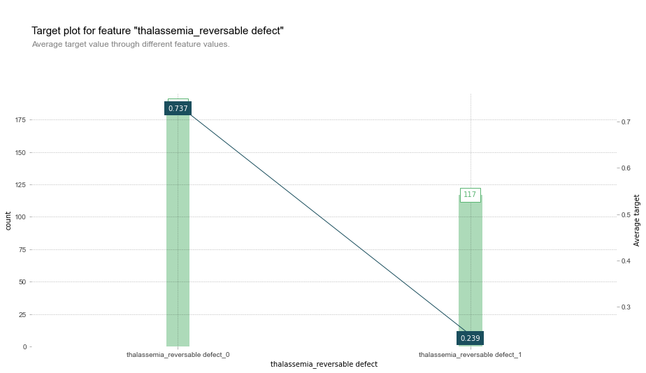

```python
fig, axes, summary_df = info_plots.target_plot(
    df=df, feature='thalassemia_reversable defect', feature_name='thalassemia_reversable defect', target=['target']
)
# _ = axes['bar_ax'].set_xticklabels(['Female', 'Male'])
```

特征：年龄

该特征统计分布，及患心脏病和不患心脏病类别分布图。

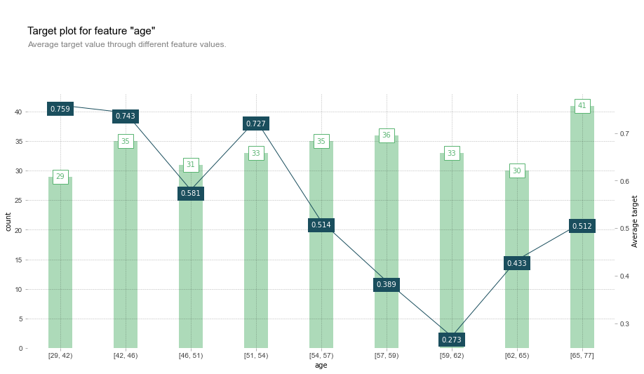

```python
fig, axes, summary_df = info_plots.target_plot(
    df=df, feature='age', feature_name='age', target=['target']
)
# _ = axes['bar_ax'].set_xticklabels(['Female', 'Male'])
```

特征：最大心率

该特征统计分布，及患心脏病和不患心脏病类别分布图。

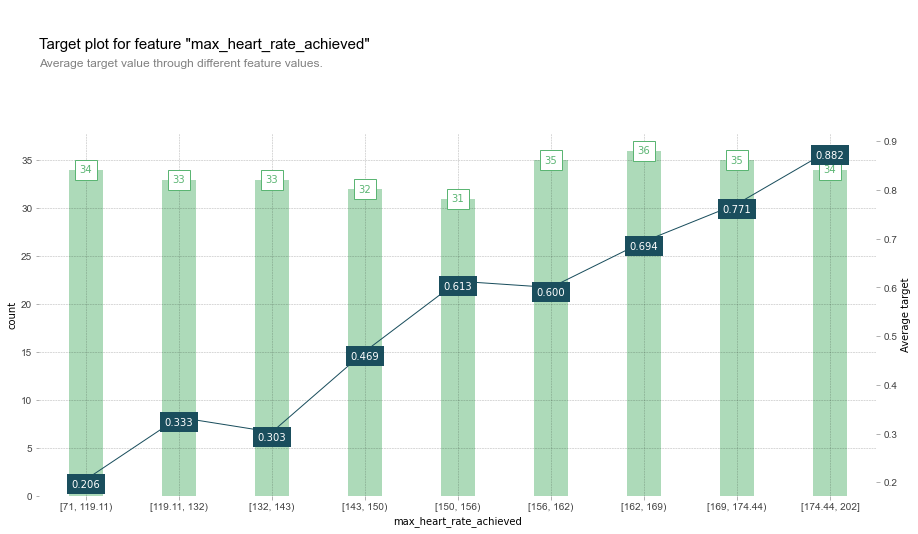

```python
fig, axes, summary_df = info_plots.target_plot(
    df=df, feature='max_heart_rate_achieved', feature_name='max_heart_rate_achieved', target=['target']
)
# _ = axes['bar_ax'].set_xticklabels(['Female', 'Male'])
```

# 特征两两交互影响分析

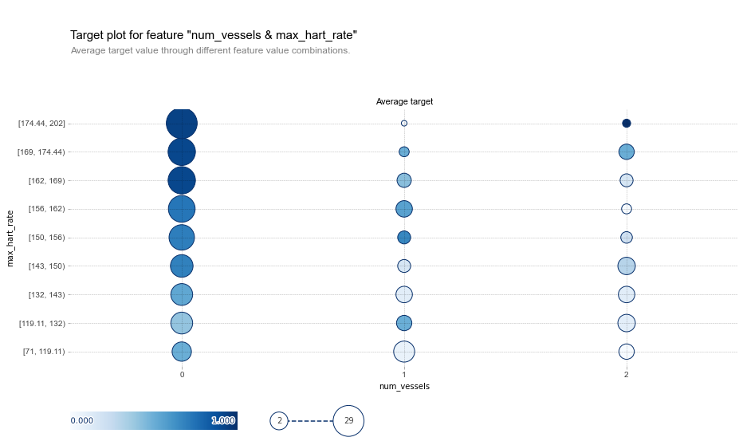

```python
feat_name1 = 'num_major_vessels'
nick_name1 = 'num_vessels'
feat_name2 = 'max_heart_rate_achieved'
nick_name2 = 'max_hart_rate'

fig, axes, summary_df = info_plots.target_plot_interact(
    df=df, features=[feat_name1, feat_name2], feature_names=[nick_name1, nick_name2], target='target'
)
axes['value_ax'].set_xticklabels(['0','1','2'])
plt.show()
```

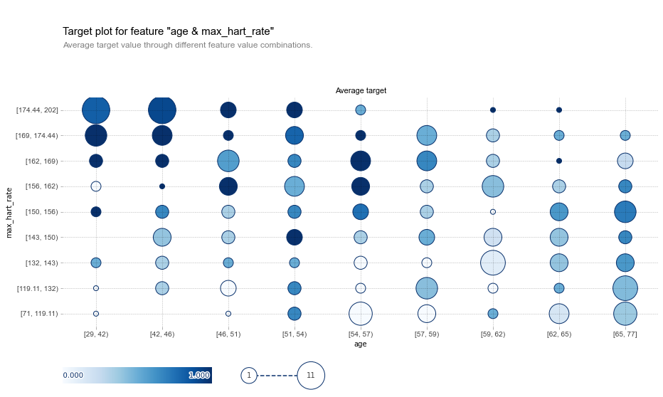

```python
feat_name1 = 'age'
nick_name1 = 'age'
feat_name2 = 'max_heart_rate_achieved'
nick_name2 = 'max_hart_rate'

fig, axes, summary_df = info_plots.target_plot_interact(
    df=df, features=[feat_name1, feat_name2], feature_names=[nick_name1, nick_name2], target='target'
)
# axes['value_ax'].set_xticklabels(['0','1','2'])
plt.show()
```